# Laboratorio 13-MD

Leislie R. Manjarrez O.

2023-02-22

Laboratorio 13- Gráficos en R con ggplot2

Instalar primero las paqueterías necesarias install.packages(“tidyverse”) install.packages(“readr”) install.packages(“ggplot2”)

Llamar a la libreria de ggplot2

```r
library(ggplot2)
```

Cargar las BD desde Files / Upload Leer los datos en la nube

```r
green_data <- read.csv("REGESIONES FINALES.csv")
```

Para visualizar los datos ejecutar el siguiente comando

```r
names(green_data)
```

```
## [1] "STATE"     "GCI_rank"  "ICE_rank"  "GCI_index" "ICE_index" "PIBE"
## [7] "LPIBE"
```

Generar primer grafico

```r
p1 <-ggplot (data =  green_data,
             mapping = aes (x = ICE_index,
                            y = GCI_index,))+
  geom_point()+
  geom_text(label = green_data$STATE,
            color = "black",
            size = 4) +
  geom_point()+
  geom_smooth(method = lm,
              se = FALSE,
              fullrange = TRUE)
```

Visualizar p1

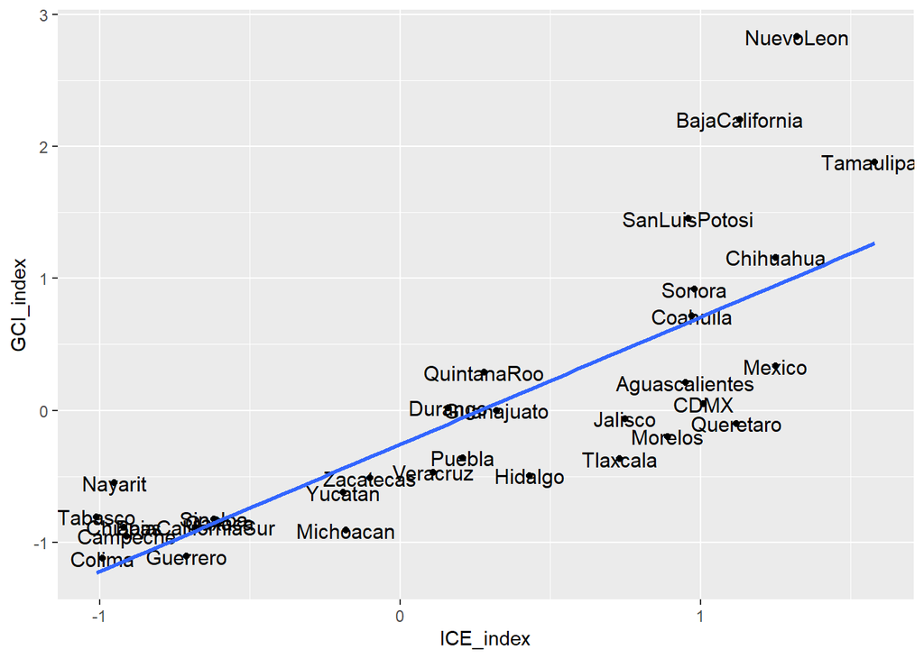

```r
p1
```

Generar un segundo grafico reciclando el codigo anterior

```r
p2 <-ggplot (data =  green_data,
             mapping = aes (x = ICE_rank,
                            y = GCI_rank,))+
  geom_point()+
  geom_text(label = green_data$STATE,
            color = "black",
            size = 4) +
  geom_point()+
  geom_smooth(method = lm,
              se = FALSE,
              fullrange = TRUE)
```

Visualizar p2

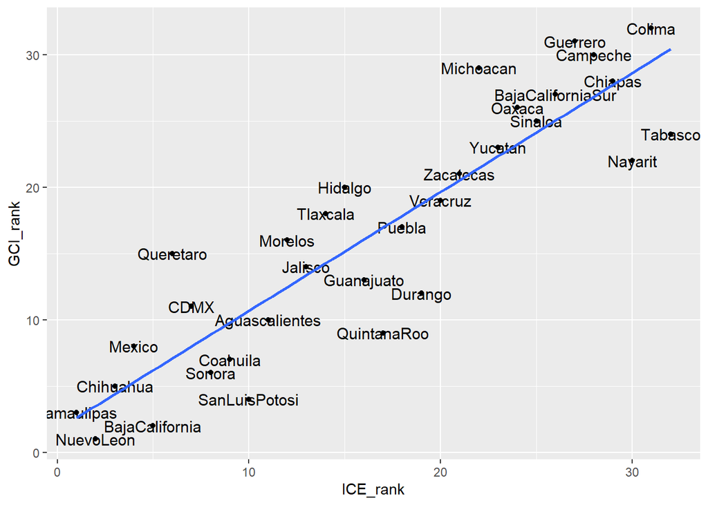

```r
p2
```

Generar un tercer grafico reciclando el codigo anterior

```r
p3 <-ggplot (data =  green_data,
             mapping = aes (x = LPIBE,
                            y = GCI_index,))+
  geom_point()+
  geom_text(label = green_data$STATE,
            color = "black",
            size = 4) +
  geom_point()+
  geom_smooth(method = lm,
              se = FALSE,
              fullrange = TRUE)
```

Visualizar p3

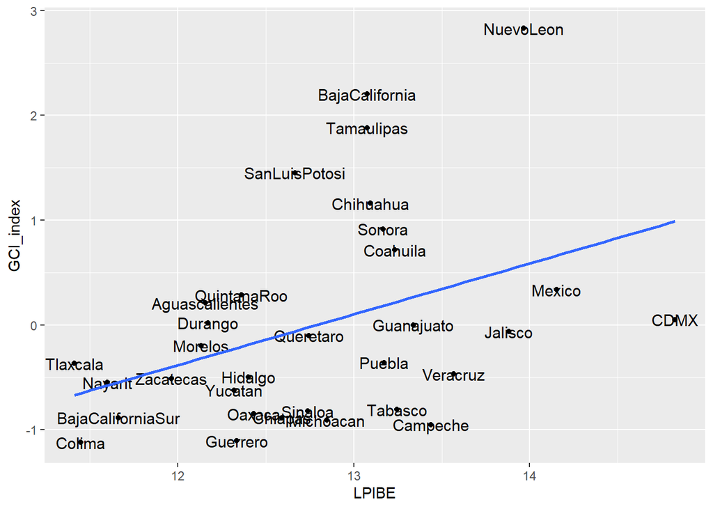

```r
p3
```

Para conocer la correlacion entre las variables primero instalar el siguiente paquete install.packages(“psych”)

Cargar posteriormente la libreria

```r
library(psych)
```

Luego cargar la libreria de readr y posteriormente crear un dataframe denominado correl

```r
library(readr)
correl <- read_csv("correl.csv")
```

Visualizar la tabla anterior

```r
head(correl)
```

```
## # A tibble: 6 × 5
##   GCI_rank ICE_rank GCI_index ICE_index LPIBE
##      <dbl>    <dbl>     <dbl>     <dbl> <dbl>
## 1       10       11     0.210      0.95  12.2
## 2        2        5     2.20       1.13  13.1
## 3       27       26    -0.885     -0.68  11.7
## 4       30       28    -0.951     -0.91  13.4
## 5       28       29    -0.885     -0.92  12.6
## 6        5        3     1.16       1.25  13.1
```

Para correlacionar de forma pariada las variables de la tabla generada con anterioridad ejecutar el siguiente comando

```r
attach(correl)
names(correl)
```

```
## [1] "GCI_rank"  "ICE_rank"  "GCI_index" "ICE_index" "LPIBE"
```

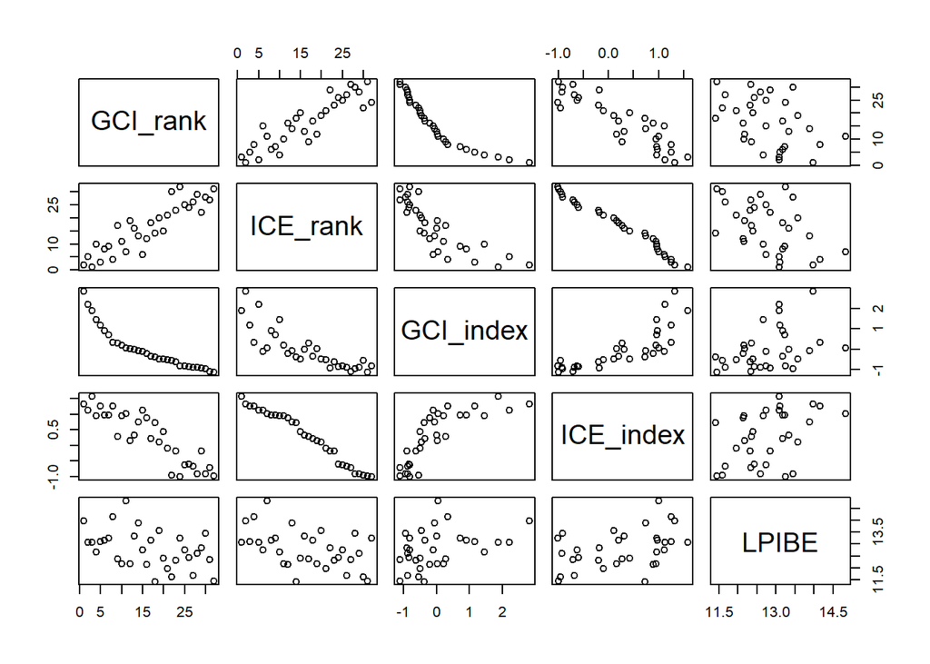

```r
pairs(correl)
```

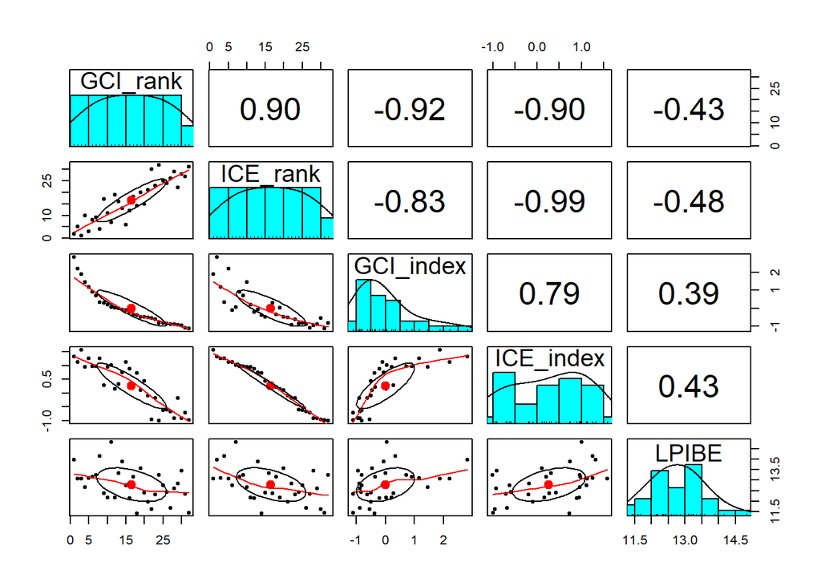

```r
pairs.panels(correl)
```

Generar otra correlacion ahora con el metodo pearson con las medidas de complejidad

```r
complex_corr <- cor(correl, method = "pearson")
```

Visualizar resultado

```r
complex_corr
```

```
##             GCI_rank   ICE_rank  GCI_index  ICE_index      LPIBE
## GCI_rank   1.0000000  0.8969941 -0.9166564 -0.8957551 -0.4288321
## ICE_rank   0.8969941  1.0000000 -0.8274473 -0.9875750 -0.4750548
## GCI_index -0.9166564 -0.8274473  1.0000000  0.7946666  0.3905008
## ICE_index -0.8957551 -0.9875750  0.7946666  1.0000000  0.4272882
## LPIBE     -0.4288321 -0.4750548  0.3905008  0.4272882  1.0000000
```

Redondear el coeficiente de correlacion y visualizar resultado

```r
complex_corr = round(complex_corr, digits = 2)
complex_corr
```

```
##           GCI_rank ICE_rank GCI_index ICE_index LPIBE
## GCI_rank      1.00     0.90     -0.92     -0.90 -0.43
## ICE_rank      0.90     1.00     -0.83     -0.99 -0.48
## GCI_index    -0.92    -0.83      1.00      0.79  0.39
## ICE_index    -0.90    -0.99      0.79      1.00  0.43
## LPIBE        -0.43    -0.48      0.39      0.43  1.00
```

Para generar un mapa de calor instalar primero paquete ggcorrplot install.packages(“ggcorrplot”)

Llamar las siguientes librerias

```r
library(ggcorrplot)
library(ggplot2)
```

Generar un grafico mas

```r
p4 <- ggcorrplot(complex_corr, method = "circle", type = "lower", lab = TRUE)+
  ggtitle("Matriz de correlación")+
  theme_minimal()
```

Visualizar resultado

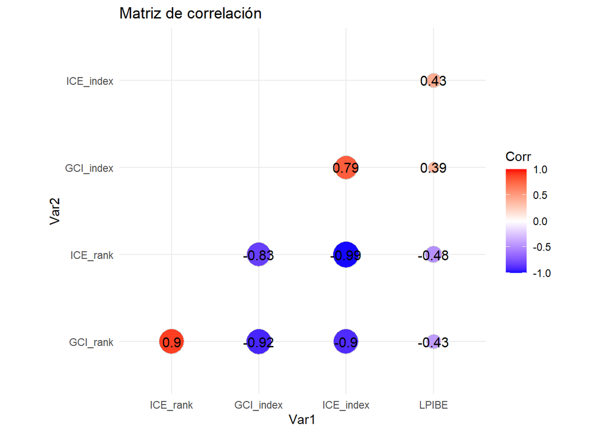

```r
p4
```

Para generar un conjunto de graficos en una sola cuadricula instalar el siguiente paquete install.packages(“ggpubr”)

Mandar llamar al paquete

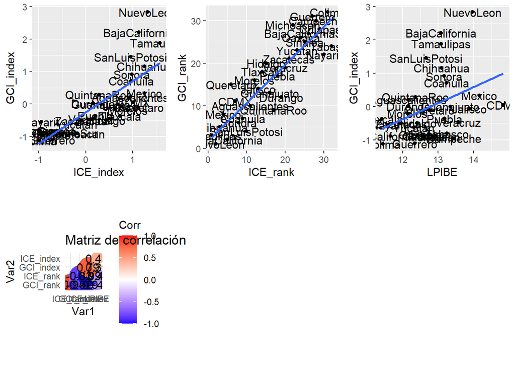

```r
require(ggpubr)
ggpubr :: ggarrange (p1, p2, p3, p4, etiquetas = c ("A", "B", "C" , "D"))
```

Para arreglar la visualización en un grid de 2X2 instalar el siguiente paquete y llamarlo

install.packages(“gridExtra”)

```r
require (gridExtra)
```

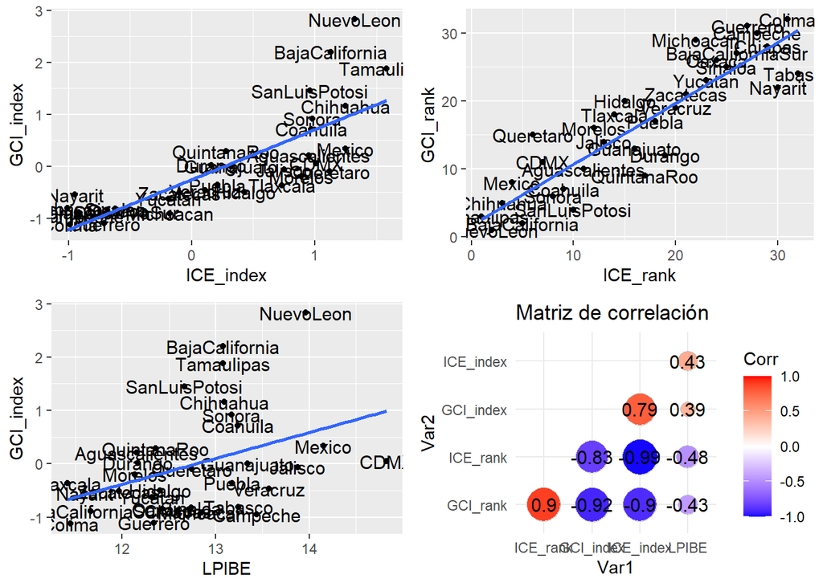

```r
F1 <- grid.arrange (p1, p2, p3, p4, nrow = 2)
```